# Machine Learning Model - Human Activity Recognition

Author: John Joyce

Date: January 22, 2018

### **Summary**

Using devices such as Jawbone Up, Nike FuelBand, and Fitbit it is now possible to collecta large amount of data about personal activity relatively inexpensively. These type of devices are part of the quantified self movement - a group of enthusiasts who take measurements about themselves regularly to improve their health, to find patterns in their behavior, or because they are tech geeks. One thing that people regularly do is quantify how much of a particular activity they do, but they rarely quantify how well they do it.

In this project, the goal is to use data from accelerometers on the belt, forearm, arm, and dumbell of six participants and predict the manner in which they did the exercise.

The participants were asked to perform barbell lifts correctly and incorrectly in five different ways, classified as follows:

```
Class A) Exactly according to specification.
Class B) Throwing the elbows to the front.
Class C) Lifting the dumbell only halfway.
Class D) Lowering the dumbell only halfway.
Class E) Throwing the hips to the front.
```

More information for this activity is available at this website: http://web.archive.org/web/20161224072740/http:/groupware.les.inf.puc-rio.br/har (Weight Lifting Exercise Dataset).

This analysis describes the following:

```
1) How was the model built?
2) How was cross validation used to verify the model?
3) What is the expected accuracy/ out of sample error?
4) Why was this model chosen?
```

Finally, this model will also be used to predict 20 different test cases.

### **Data Analysis**

The training data used for this model are available at https://d396qusza40orc.cloudfront.net/predmachlearn/pml-training.csv.  
The test data used for this model are available at https://d396qusza40orc.cloudfront.net/predmachlearn/pml-testing.csv.

#### **Load Packages & Import Data**

This section installs/loads the required packages if they are not already loaded. This section also loads the training and testing data sets used for the modeling.

```r
##  Install the required packages

    if (!require("caret")) install.packages("caret")
    if (!require("rpart")) install.packages("rpart")
    if (!require("rattle")) install.packages("rattle")
    if (!require("randomForest")) install.packages("randomForest")
    if (!require("gbm")) install.packages("gbm")
    if (!require("knitr")) install.packages("knitr")
    if (!require("corrplot")) install.packages("corrplot")

##  Load the required packages.

    library(caret)
    library(rpart)
    library(rattle)
    library(randomForest)
    library(gbm)
    library(knitr)
    library(corrplot)

##  Load the concrete data set.

    training_ds  <- read.csv("https://d396qusza40orc.cloudfront.net/predmachlearn/pml-training.csv",
                             na.strings = c("NA", "", "#DIV/0!"))
    testing_ds   <- read.csv("https://d396qusza40orc.cloudfront.net/predmachlearn/pml-testing.csv",
                             na.strings = c("NA", "", "#DIV/0!"))
```

This section reviews and cleans the training and test data sets.

```r
##  Review the dimensions of the training and test data sets.

    dim(training_ds)
```

```
## [1] 19622   160
```

```r
    dim(testing_ds)
```

```
## [1]  20 160
```

```r
##  Review the data variable types in the training and test data sets.
##  Output omitted from report for simplicity.

    str(training_ds)
    str(testing_ds)
    head(training_ds)
    head(testing_ds)
```

Evaluating the data reveals that there are alot of NA values. This analysis will remove columns (predictors) that have greater than 75% of the data that is not useable (zeroes, NAs, etc).

```r
##  Remove columns which contain greater than or equal to 75% NAs from training and test data sets.

    training_ds  <- training_ds[, -which(colMeans(is.na(training_ds)) > 0.75)]
    testing_ds   <-testing_ds[, -which(colMeans(is.na(testing_ds)) > 0.75)]

##  Verify that all of the NAs have been removed from the training and test data sets.

    sum(is.na(training_ds))
```

```
## [1] 0
```

```r
    sum(is.na(testing_ds))
```

```
## [1] 0
```

```r
##  Remove unrelated text related columns (1-7).

    training_ds  <- training_ds[,-c(1:7)]
    testing_ds   <- testing_ds[,-c(1:7)]
```

The resulting cleaned data sets have the following dimensions.

```r
##  Review the dimensions of the training and test data sets.

    dim(training_ds)
```

```
## [1] 19622    53
```

```r
    dim(testing_ds)
```

```
## [1] 20 53
```

### **Modeling**

This section outlines the modeling methods (classification tree, random forest, and boosting) used for this prediction model. The model is developed to predict the “classe” variable.

#### **Data Splitting**

This section sets a random seed and splits the training data set into a training and test data set (70/30 split).

```r
##  Set a seed = 2000

    set.seed(2000)

##  Split the training data set into a training (70%) and test data sets (30%).

    inTrain     <- createDataPartition(training_ds$classe,p=.7,list = FALSE)
    training    <- training_ds[inTrain,]
    testing     <- training_ds[-inTrain,]

    dim(training)
```

```
## [1] 13737    53
```

```r
    dim(testing)
```

```
## [1] 5885   53
```

#### **Classification Tree Model**

This section outlines the Classification Tree Modeling methods and results. The model uses the trainControl function to perform cross validation with k = 5. The rattle package is used to plot the classification tree shown and the confusionMatrix function is used to calculate the accuracy of this model, which is found to be approx 50%.

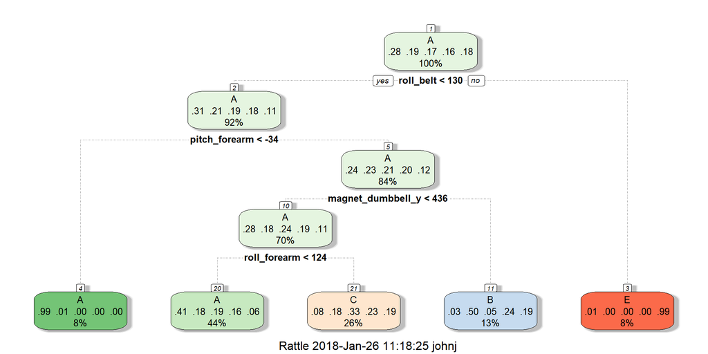

```r
##  Set train control settings

    mod_trControl <- trainControl(method = "cv", number = 5)

##  Create a classification tree model using the rpart method to fit the data.

    modFit_rpart <- train(classe~., data=training, method = "rpart", trControl = mod_trControl)
    fancyRpartPlot(modFit_rpart$finalModel)
```

The validation test set is used to predict the accuracy of this model.

```r
##  Use a confusion matrix to generate the prediction output.

    predict_rpart <- predict(modFit_rpart, testing)
    confMatrix_rpart <- confusionMatrix(testing$classe, predict_rpart)
    confMatrix_rpart
```

```
## Confusion Matrix and Statistics
##
##           Reference
## Prediction    A    B    C    D    E
##          A 1510   34  129    0    1
##          B  461  403  275    0    0
##          C  465   25  536    0    0
##          D  460  152  352    0    0
##          E  164  157  270    0  491
##
## Overall Statistics
##
##                Accuracy : 0.4996
##                  95% CI : (0.4867, 0.5124)
##     No Information Rate : 0.52
##     P-Value [Acc > NIR] : 0.9992
##
##                   Kappa : 0.3459
##  Mcnemar's Test P-Value : NA
##
## Statistics by Class:
##
##                      Class: A Class: B Class: C Class: D Class: E
## Sensitivity            0.4935  0.52270  0.34315       NA  0.99797
## Specificity            0.9419  0.85608  0.88665   0.8362  0.89041
## Pos Pred Value         0.9020  0.35382  0.52242       NA  0.45379
## Neg Pred Value         0.6319  0.92246  0.78885       NA  0.99979
## Prevalence             0.5200  0.13101  0.26542   0.0000  0.08360
## Detection Rate         0.2566  0.06848  0.09108   0.0000  0.08343
## Detection Prevalence   0.2845  0.19354  0.17434   0.1638  0.18386
## Balanced Accuracy      0.7177  0.68939  0.61490       NA  0.94419
```

#### **Random Forest Model**

This section outlines the Random Forest Modeling methods and results.

```r
##  Create a random forest model using the rf method to fit the data.

    modFit_rf <- randomForest(classe~., data=training, importance=TRUE)
```

The validation test set is used to predict the accuracy of this model. The confusionMatrix function is used to calculate the accuracy of this model, which is found to be approx 99.5%.

```r
##  Use a confusion matrix to generate the prediction output.

    predict_rf <- predict(modFit_rf, testing)
    confMatrix_rf <- confusionMatrix(testing$classe, predict_rf)
    confMatrix_rf
```

```
## Confusion Matrix and Statistics
##
##           Reference
## Prediction    A    B    C    D    E
##          A 1671    2    0    0    1
##          B    3 1133    3    0    0
##          C    0    3 1023    0    0
##          D    0    0   10  953    1
##          E    0    0    1    3 1078
##
## Overall Statistics
##
##                Accuracy : 0.9954
##                  95% CI : (0.9933, 0.997)
##     No Information Rate : 0.2845
##     P-Value [Acc > NIR] : < 2.2e-16
##
##                   Kappa : 0.9942
##  Mcnemar's Test P-Value : NA
##
## Statistics by Class:
##
##                      Class: A Class: B Class: C Class: D Class: E
## Sensitivity            0.9982   0.9956   0.9865   0.9969   0.9981
## Specificity            0.9993   0.9987   0.9994   0.9978   0.9992
## Pos Pred Value         0.9982   0.9947   0.9971   0.9886   0.9963
## Neg Pred Value         0.9993   0.9989   0.9971   0.9994   0.9996
## Prevalence             0.2845   0.1934   0.1762   0.1624   0.1835
## Detection Rate         0.2839   0.1925   0.1738   0.1619   0.1832
## Detection Prevalence   0.2845   0.1935   0.1743   0.1638   0.1839
## Balanced Accuracy      0.9987   0.9972   0.9929   0.9973   0.9987
```

#### **Generalized Boosted Model**

This section outlines the Generalized Boosted Modeling methods and results.

```r
##  Create a random generalized boosted model using the gbm method to fit the data.

    modFit_gbm <- train(classe~., data=training, method = "gbm", trControl = mod_trControl, verbose=FALSE)
```

The validation test set is used to predict the accuracy of this model. The confusionMatrix function is used to calculate the accuracy of this model, which is found to be approx 95.9%.

```r
##  Use a confusion matrix to generate the prediction output.

    predict_gbm <- predict(modFit_gbm, testing)
    confMatrix_gbm <- confusionMatrix(testing$classe, predict_gbm)
    confMatrix_gbm
```

```
## Confusion Matrix and Statistics
##
##           Reference
## Prediction    A    B    C    D    E
##          A 1652   17    4    1    0
##          B   33 1067   33    4    2
##          C    0   36  976   12    2
##          D    2    6   34  916    6
##          E    2   24    6   17 1033
##
## Overall Statistics
##
##                Accuracy : 0.959
##                  95% CI : (0.9537, 0.964)
##     No Information Rate : 0.287
##     P-Value [Acc > NIR] : < 2.2e-16
##
##                   Kappa : 0.9482
##  Mcnemar's Test P-Value : 5.286e-07
##
## Statistics by Class:
##
##                      Class: A Class: B Class: C Class: D Class: E
## Sensitivity            0.9781   0.9278   0.9269   0.9642   0.9904
## Specificity            0.9948   0.9848   0.9897   0.9903   0.9899
## Pos Pred Value         0.9869   0.9368   0.9513   0.9502   0.9547
## Neg Pred Value         0.9912   0.9825   0.9842   0.9931   0.9979
## Prevalence             0.2870   0.1954   0.1789   0.1614   0.1772
## Detection Rate         0.2807   0.1813   0.1658   0.1556   0.1755
## Detection Prevalence   0.2845   0.1935   0.1743   0.1638   0.1839
## Balanced Accuracy      0.9864   0.9563   0.9583   0.9772   0.9901
```

After comparing the accuracy of the classification tree, random forest, and generalied boosted model; the random forest model is used with (accuracy = 99.5%) to predit the test data set (test_ds).

```r
##  Use a confusion matrix to generate the prediction output.

    predict(modFit_rf, testing_ds)
```

```
##  1  2  3  4  5  6  7  8  9 10 11 12 13 14 15 16 17 18 19 20
##  B  A  B  A  A  E  D  B  A  A  B  C  B  A  E  E  A  B  B  B
## Levels: A B C D E
```

### **Raw Code**

```r
##  Install the required packages

    if (!require("caret")) install.packages("caret")
    if (!require("rpart")) install.packages("rpart")
    if (!require("rattle")) install.packages("rattle")
    if (!require("randomForest")) install.packages("randomForest")
    if (!require("gbm")) install.packages("gbm")
    if (!require("knitr")) install.packages("knitr")
    if (!require("corrplot")) install.packages("corrplot")

##  Load the required packages.

    library(caret)
    library(rpart)
    library(rattle)
    library(randomForest)
    library(gbm)
    library(knitr)
    library(corrplot)

##  Load the concrete data set.

    training_ds  <- read.csv("https://d396qusza40orc.cloudfront.net/predmachlearn/pml-training.csv",
                             na.strings = c("NA", "", "#DIV/0!"))
    testing_ds   <- read.csv("https://d396qusza40orc.cloudfront.net/predmachlearn/pml-testing.csv",
                             na.strings = c("NA", "", "#DIV/0!"))
##  Review the dimensions of the training and test data sets.

    dim(training_ds)
    dim(testing_ds)

    ##  Review the data variable types in the training and test data sets.
##  Output omitted from report for simplicity.

    str(training_ds)
    str(testing_ds)
    head(training_ds)
    head(testing_ds)

##  Remove columns which contain greater than or equal to 75% NAs from training and test data sets.

    training_ds  <- training_ds[, -which(colMeans(is.na(training_ds)) > 0.75)]
    testing_ds   <-testing_ds[, -which(colMeans(is.na(testing_ds)) > 0.75)]

##  Verify that all of the NAs have been removed from the training and test data sets.

    sum(is.na(training_ds))
    sum(is.na(testing_ds))

##  Remove unrelated text related columns (1-7).

    training_ds  <- training_ds[,-c(1:7)]
    testing_ds   <- testing_ds[,-c(1:7)]

##  Review the dimensions of the training and test data sets.

    dim(training_ds)
    dim(testing_ds)

##  Set train control settings

    mod_trControl <- trainControl(method = "cv", number = 5)

##  Create a classification tree model using the rpart method to fit the data.

    modFit_rpart <- train(classe~., data=training, method = "rpart", trControl = mod_trControl)
    fancyRpartPlot(modFit_rpart$finalModel)

##  Use a confusion matrix to generate the prediction output.

    predict_rpart <- predict(modFit_rpart, testing)
    confMatrix_rpart <- confusionMatrix(testing$classe, predict_rpart)
    confMatrix_rpart

##  Create a random forest model using the rf method to fit the data.

    modFit_rf <- randomForest(classe~., data=training, importance=TRUE)

##  Use a confusion matrix to generate the prediction output.

    predict_rf <- predict(modFit_rf, testing)
    confMatrix_rf <- confusionMatrix(testing$classe, predict_rf)
    confMatrix_rf

##  Create a random generalized boosted model using the gbm method to fit the data.

    modFit_gbm <- train(classe~., data=training, method = "gbm", trControl = mod_trControl, verbose=FALSE)

##  Use a confusion matrix to generate the prediction output.

    predict_gbm <- predict(modFit_gbm, testing)
    confMatrix_gbm <- confusionMatrix(testing$classe, predict_gbm)
    confMatrix_gbm

##  Use a confusion matrix to generate the prediction output.

    predict(modFit_rf, testing_ds)
```